# Статистический анализ данных (Задание 2)

Мурат Апишев, группа №417

Среда, 18 марта, 2015

В данном задании имеются данные о разрушающих моментах промышленных вентиляторов, даны характеристики этих вентиляторов. Требуется определить, зависит ли значение разрушающего момента от характеристик вентиляторов.

Данные представляют собой выборку $X^n = \{x_i\}_{i = 1}^n$, где $n = 64$, а каждый элементы выборки характеризуется 4-мя значениями:

- Тип отверстия (бинарный признак, значения {‘круглое’, ‘шестиугольное’})
- Метод соединения (бинарный признак, значения {‘паз’, ‘резьба’})
- Форма барабана (бинарный признак, значения {‘гладкий’, ‘гофрированный’})
- Разрушающий крутящий момент (непрерывный признак)

Перед использованием, данные были преобразованы: была удалена строка с заголовками столбцов (названиями признаков) и все значения-строки были переведены на английский язык для того, чтобы избежать проблем с кодировками. Переводы получились следующие:

- {‘круглое’ —> ‘circle’, ‘шестиугольное’ —> ‘hexagon’}
- {‘паз’ —> ‘groove’, ‘резьба’ —> ‘thread’}
- {‘гладкий’ —> ‘plain’, ‘гофрированный’ —> ‘corrugated’}

Предлагается следующая схема решения поставленной задачи. Для каждого бинарного признака значения разрушающего момента делятся на две части (в соответствии со значением бинарного признака). Затем две полученные независимые выборки подаются на вход соответствующему статистическому критерию, проверяющему гипотезу о том, что они порождены одним вероятностным распределением. Опровержение гипотезы равносильно наличию зависимости между разрушающим моментом и данной характеристикой вентилятора.

Будем использовать два статистических критерия, подходящих для решения данной задачи: критерий Колмогорова-Смирнова и критерий Андерсона-Дарлинга. В качестве уровня значимости $\alpha$ возьмём 0.05.

Для использования указанных выше критериев требуется подключить соответствующие библиотеки

```r
library('stats')
library('adk')
```

Следующим шагом загрузим исходные данные в data.frame

```r
sample <- read.table('fans_eng.txt')
```

Проведём анализ зависимостей, связанных с первым признаком

```r
indices <- sample[, 1] == 'circle'
sample_1 <- as.numeric(gsub(",", ".", c(matrix(sample[indices, 4]))))
sample_2 <- as.numeric(gsub(",", ".", c(matrix(sample[!indices, 4]))))
ks.test(sample_1, sample_2)
```

[output not shown]

Получили допустимый уровень значимости 0.27, что не позволяет отвергнуть гипотезу о том, что выборки получены из одного распределения. Получается, что данный критерий допускает возможность независимости разрушающего момента вентилятора от признака ‘Тип отверстия’.

Теперь подадим те же данные на вход критерию Андерсона-Дарлинга:

```r
adk.test(sample_1, sample_2)
```

[output not shown]

Получили p-value равный 0.08, что подтверждает предыдущий вывод, хотя и в меньшей степени.

Исследуем теперь взаимосвязь разрушающего момента и признака ‘Метод соединения’

```r
indices <- sample[, 2] == 'groove'
sample_1 <- as.numeric(gsub(",", ".", c(matrix(sample[indices, 4]))))
sample_2 <- as.numeric(gsub(",", ".", c(matrix(sample[!indices, 4]))))
ks.test(sample_1, sample_2)
adk.test(sample_1, sample_2)
```

[output not shown]

Допустимые уровни значимости, полученные в результате, равны 0.01 и 3.8e-4 для критериев Колмогорова-Смирнова и Андерсона-Дарлинга соответственно. Это позволяет уверенно отвергнуть гипотезу общего наличия общего для обеих выборок порождающего распределения. Таким образом, разрушающий момент вентилятора зависит от признака ‘Метод соединения’.

Рассмотрим связь разрушающего момента с последним бинарным признаком

```r
indices <- sample[, 3] == 'plain'
sample_1 <- as.numeric(gsub(",", ".", c(matrix(sample[indices, 4]))))
sample_2 <- as.numeric(gsub(",", ".", c(matrix(sample[!indices, 4]))))
ks.test(sample_1, sample_2)
adk.test(sample_1, sample_2)
```

[output not shown]

p-value получились 2.5e-14 и 0, что показывает наличие сильной взаимосвязи между разрушающим моментом вентилятора и значеним его признака ‘Форма барабана’.

Теперь применим трёхфакторный дисперсионный анализ для определения значимости влияния в совокупности всех характеристик вентилятора на разрушающий крутящий момент

```r
names(sample) <- c('type', 'method', 'form', 'moment')
sample <- transform(sample, moment = as.numeric(gsub(",", ".", moment)))
aov_res <- aov(moment ~ type * method * form, data=sample)
summary(aov_res)
```

```
##                  Df Sum Sq Mean Sq  F value   Pr(>F)
## type              1  15180   15180  266.677  < 2e-16 ***
## method            1  24576   24576  431.741  < 2e-16 ***
## form              1 354876  354876 6234.311  < 2e-16 ***
## type:method       1   5236    5236   91.990 2.03e-13 ***
## type:form         1   1092    1092   19.189 5.24e-05 ***
## method:form       1    248     248    4.363   0.0413 *
## type:method:form  1   2568    2568   45.113 1.02e-08 ***
## Residuals        56   3188      57
## ---
## Signif. codes:  0 '***' 0.001 '**' 0.01 '*' 0.05 '.' 0.1 ' ' 1
```

Построим необходимые графики

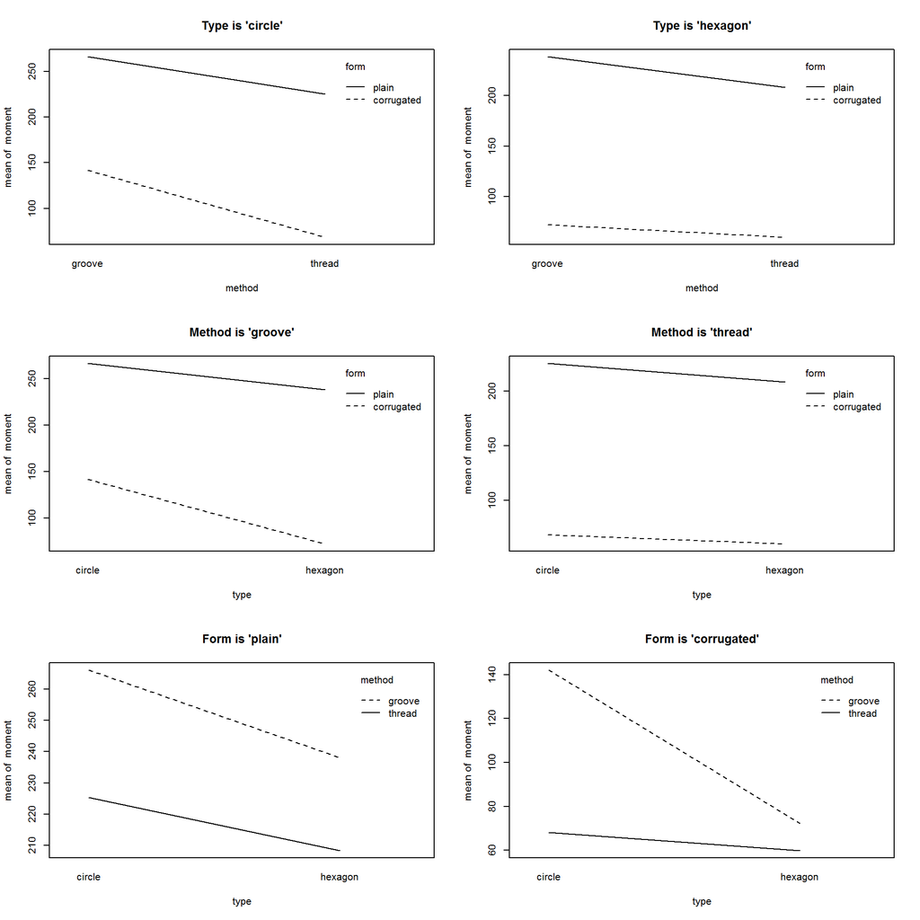

```r
par(mfrow = c(3, 2))
with(sample[sample$type == "circle", ],  interaction.plot(method, form, moment, main = "Type is 'circle'"))
with(sample[sample$type == "hexagon", ],  interaction.plot(method, form, moment, main = "Type is 'hexagon'"))

with(sample[sample$method == "groove", ],  interaction.plot(type, form, moment, main = "Method is 'groove'"))
with(sample[sample$method == "thread", ],  interaction.plot(type, form, moment, main = "Method is 'thread'"))

with(sample[sample$form == "plain", ],  interaction.plot(type, method, moment, main = "Form is 'plain'"))
with(sample[sample$form == "corrugated", ],  interaction.plot(type, method, moment, main = "Form is 'corrugated'"))
```

Тройное взаимодействие значимо, поэтому разделим выборку по одному из признаков.

Проведём двухфакторный дисперсионный анализ для вентиляторов с круглым типом отверстия:

```r
aov_res2 <- aov(moment ~ method * form, data=subset(sample, type == "circle"))
summary(aov_res2)
```

```
##             Df Sum Sq Mean Sq F value   Pr(>F)
## method       1  26250   26250  655.61  < 2e-16 ***
## form         1 158296  158296 3953.51  < 2e-16 ***
## method:form  1   2207    2207   55.12 4.38e-08 ***
## Residuals   28   1121      40
## ---
## Signif. codes:  0 '***' 0.001 '**' 0.01 '*' 0.05 '.' 0.1 ' ' 1
```

```r
library(DescTools)
EtaSq(aov_res2, type=1)
```

```
##                 eta.sq eta.sq.part
## method      0.13972268   0.9590411
## form        0.84256383   0.9929675
## method:form 0.01174619   0.6631213
```

Присутствует значимое межфакторное взаимодействие:

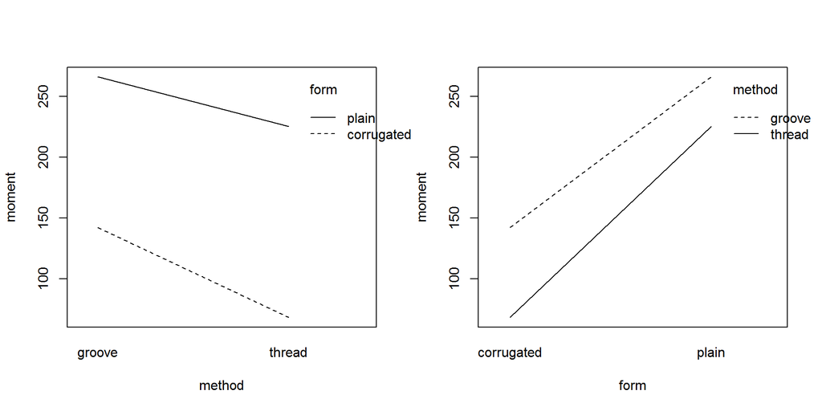

```r
par(mfrow=c(1,2))
with(sample[sample$type == "circle", ], interaction.plot(method, form, moment, xlab="method", ylab="moment"))
with(sample[sample$type == "circle", ], interaction.plot(form, method, moment, xlab="form", ylab="moment"))
```

Поэтому снова поделим выборку.

Однофакторный анализ для вентиляторов с круглым отверстием и пазовым соединением:

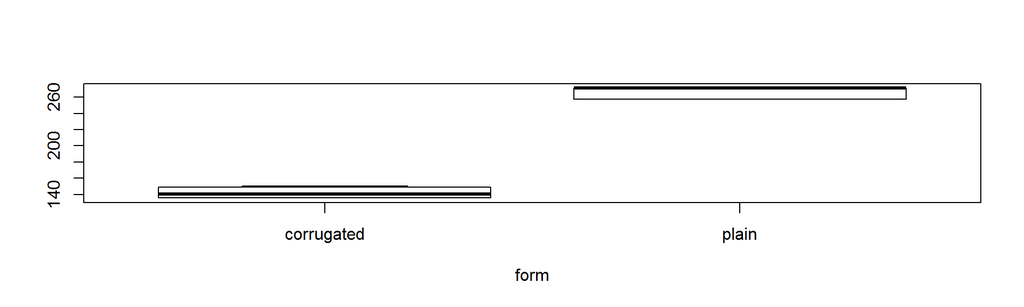

```r
boxplot(moment ~ form, data=subset(sample, type == "circle" & method == "groove"), xlab="form")
```

```r
aov_res21 <- aov(moment ~ form, data=subset(sample, type == "circle" & method == "groove"))
summary(aov_res21)
```

```
##             Df Sum Sq Mean Sq F value   Pr(>F)
## form         1  61561   61561    1314 3.05e-15 ***
## Residuals   14    656      47
## ---
## Signif. codes:  0 '***' 0.001 '**' 0.01 '*' 0.05 '.' 0.1 ' ' 1
```

```r
EtaSq(aov_res21, type=1)
```

```
##         eta.sq eta.sq.part
## form 0.9894562   0.9894562
```

```r
TukeyHSD(aov_res21)
```

```
##   Tukey multiple comparisons of means
##     95% family-wise confidence level
##
## Fit: aov(formula = moment ~ form, data = subset(sample, type == "circle" & method == "groove"))
##
## $form
##                      diff      lwr      upr p adj
## plain-corrugated 124.0575 116.7167 131.3983     0
```

Однофакторный анализ для вентиляторов с круглым отверстием и резьбовым соединением:

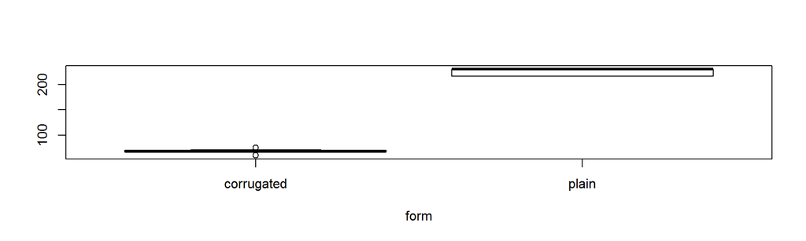

```r
boxplot(moment ~ form, data=subset(sample, type == "circle" & method == "thread"), xlab="form")
```

```r
aov_res22 <- aov(moment ~ form, data=subset(sample, type == "circle" & method == "thread"))
summary(aov_res22)
```

```
##             Df Sum Sq Mean Sq F value Pr(>F)
## form         1  98942   98942    2978 <2e-16 ***
## Residuals   14    465      33
## ---
## Signif. codes:  0 '***' 0.001 '**' 0.01 '*' 0.05 '.' 0.1 ' ' 1
```

```r
EtaSq(aov_res22, type=1)
```

```
##         eta.sq eta.sq.part
## form 0.9953213   0.9953213
```

```r
TukeyHSD(aov_res22)
```

```
##   Tukey multiple comparisons of means
##     95% family-wise confidence level
##
## Fit: aov(formula = moment ~ form, data = subset(sample, type == "circle" & method == "thread"))
##
## $form
##                     diff     lwr     upr p adj
## plain-corrugated 157.275 151.094 163.456     0
```

Однофакторный анализ для вентиляторов с круглым отверстием и плоским барабаном:

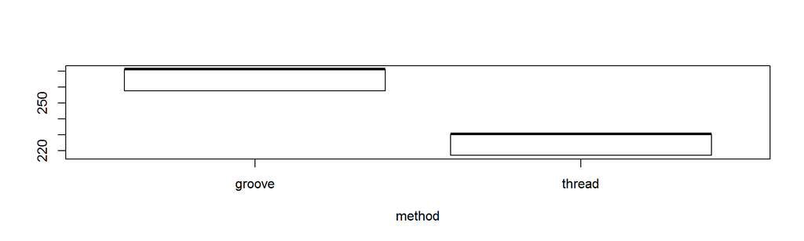

```r
boxplot(moment ~ method, data=subset(sample, type == "circle" & form == "plain"), xlab="method")
```

```r
aov_res23 <- aov(moment ~ method, data=subset(sample, type == "circle" & form == "plain"))
summary(aov_res23)
```

```
##             Df Sum Sq Mean Sq F value   Pr(>F)
## method       1   6617    6617   134.5 1.45e-08 ***
## Residuals   14    689      49
## ---
## Signif. codes:  0 '***' 0.001 '**' 0.01 '*' 0.05 '.' 0.1 ' ' 1
```

```r
EtaSq(aov_res23, type=1)
```

```
##           eta.sq eta.sq.part
## method 0.9056971   0.9056971
```

```r
TukeyHSD(aov_res23)
```

```
##   Tukey multiple comparisons of means
##     95% family-wise confidence level
##
## Fit: aov(formula = moment ~ method, data = subset(sample, type == "circle" & form == "plain"))
##
## $method
##                    diff     lwr      upr p adj
## thread-groove -40.67375 -48.197 -33.1505     0
```

Однофакторный анализ для вентиляторов с круглым отверстием и гофрированным барабаном:

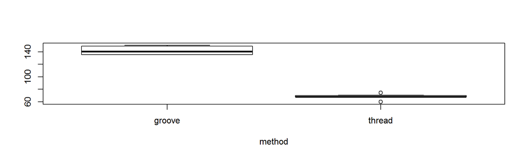

```r
boxplot(moment ~ method, data=subset(sample, type == "circle" & form == "corrugated"), xlab="method")
```

```r
aov_res24 <- aov(moment ~ method, data=subset(sample, type == "circle" & form == "corrugated"))
summary(aov_res24)
```

```
##             Df Sum Sq Mean Sq F value   Pr(>F)
## method       1  21840   21840   707.6 2.19e-13 ***
## Residuals   14    432      31
## ---
## Signif. codes:  0 '***' 0.001 '**' 0.01 '*' 0.05 '.' 0.1 ' ' 1
```

```r
EtaSq(aov_res24, type=1)
```

```
##           eta.sq eta.sq.part
## method 0.9805995   0.9805995
```

```r
TukeyHSD(aov_res24)
```

```
##   Tukey multiple comparisons of means
##     95% family-wise confidence level
##
## Fit: aov(formula = moment ~ method, data = subset(sample, type == "circle" & form == "corrugated"))
##
## $method
##                    diff       lwr       upr p adj
## thread-groove -73.89125 -79.84888 -67.93362     0
```

Выводы следующие:

1. Круглый тип + пазовый метод —> плоская форма лучше на 124, интервал [116, 131], p-value = 0.
2. Круглый тип + резьбовой метод —> плоская форма лучше на 157, интервал [151, 163], p-value = 0.
3. Круглый тип + плоская форма —> резьбовой метод хуже на 40, интервал [-48, -33], p-value = 0.
4. Круглый тип + гофрированная форма —> резьбовой метод хуже на 74, интервал [-80, -68], p-value = 0.

Проведём двухфакторный дисперсионный анализ для вентиляторов с шестиугольным типом отверстия:

```r
aov_res3 <- aov(moment ~ method * form, data=subset(sample, type == "hexagon"))
summary(aov_res3)
```

```
##             Df Sum Sq Mean Sq  F value   Pr(>F)
## method       1   3562    3562   48.262 1.49e-07 ***
## form         1 197673  197673 2678.241  < 2e-16 ***
## method:form  1    610     610    8.258  0.00766 **
## Residuals   28   2067      74
## ---
## Signif. codes:  0 '***' 0.001 '**' 0.01 '*' 0.05 '.' 0.1 ' ' 1
```

```r
EtaSq(aov_res3, type=1)
```

```
##                 eta.sq eta.sq.part
## method      0.01746891   0.6328468
## form        0.96940711   0.9896535
## method:form 0.00298919   0.2277656
```

Присутствует значимое межфакторное взаимодействие:

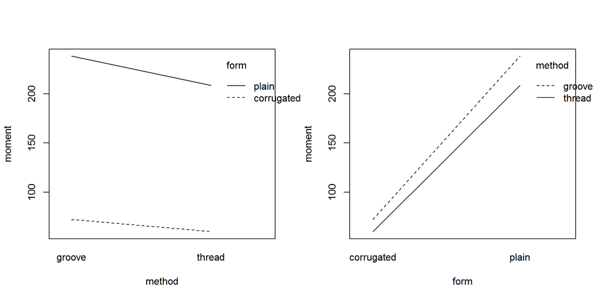

```r
par(mfrow=c(1,2))
with(sample[sample$type == "hexagon", ], interaction.plot(method, form, moment, xlab="method", ylab="moment"))
with(sample[sample$type == "hexagon", ], interaction.plot(form, method, moment, xlab="form", ylab="moment"))
```

Поэтому снова поделим выборку.

Однофакторный анализ для вентиляторов с шестиугольным отверстием и пазовым соединением:

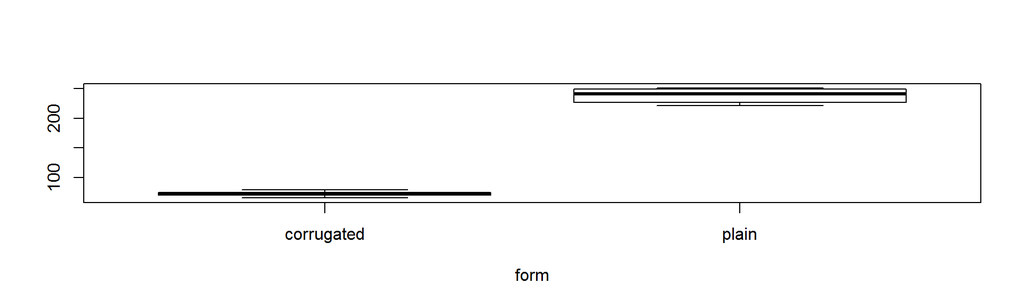

```r
boxplot(moment ~ form, data=subset(sample, type == "hexagon" & method == "groove"), xlab="form")
```

```r
aov_res31 <- aov(moment ~ form, data=subset(sample, type == "hexagon" & method == "groove"))
summary(aov_res31)
```

```
##             Df Sum Sq Mean Sq F value   Pr(>F)
## form         1 110118  110118    1390 2.07e-15 ***
## Residuals   14   1109      79
## ---
## Signif. codes:  0 '***' 0.001 '**' 0.01 '*' 0.05 '.' 0.1 ' ' 1
```

```r
EtaSq(aov_res31, type=1)
```

```
##         eta.sq eta.sq.part
## form 0.9900266   0.9900266
```

```r
TukeyHSD(aov_res31)
```

```
##   Tukey multiple comparisons of means
##     95% family-wise confidence level
##
## Fit: aov(formula = moment ~ form, data = subset(sample, type == "hexagon" & method == "groove"))
##
## $form
##                    diff      lwr      upr p adj
## plain-corrugated 165.92 156.3741 175.4659     0
```

Однофакторный анализ для вентиляторов с шестиугольным отверстием и резьбовым соединением:

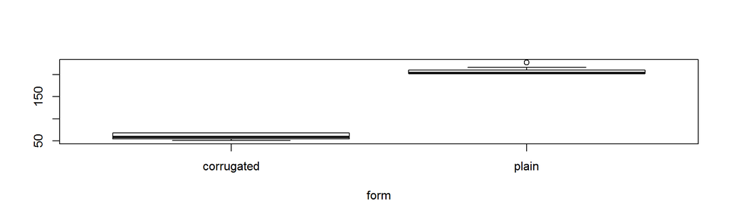

```r
boxplot(moment ~ form, data=subset(sample, type == "hexagon" & method == "thread"), xlab="form")
```

```r
aov_res32 <- aov(moment ~ form, data=subset(sample, type == "hexagon" & method == "thread"))
summary(aov_res32)
```

```
##             Df Sum Sq Mean Sq F value   Pr(>F)
## form         1  88164   88164    1289 3.47e-15 ***
## Residuals   14    957      68
## ---
## Signif. codes:  0 '***' 0.001 '**' 0.01 '*' 0.05 '.' 0.1 ' ' 1
```

```r
EtaSq(aov_res32, type=1)
```

```
##         eta.sq eta.sq.part
## form 0.9892587   0.9892587
```

```r
TukeyHSD(aov_res32)
```

```
##   Tukey multiple comparisons of means
##     95% family-wise confidence level
##
## Fit: aov(formula = moment ~ form, data = subset(sample, type == "hexagon" & method == "thread"))
##
## $form
##                      diff      lwr      upr p adj
## plain-corrugated 148.4625 139.5948 157.3302     0
```

Однофакторный анализ для вентиляторов с шестиугольным отверстием и плоским барабаном:

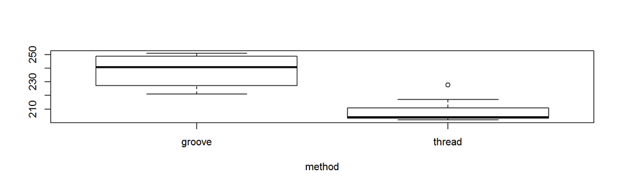

```r
boxplot(moment ~ method, data=subset(sample, type == "hexagon" & form == "plain"), xlab="method")
```

```r
aov_res33 <- aov(moment ~ method, data=subset(sample, type == "hexagon" & form == "plain"))
summary(aov_res33)
```

```
##             Df Sum Sq Mean Sq F value   Pr(>F)
## method       1   3559    3559   31.45 6.45e-05 ***
## Residuals   14   1584     113
## ---
## Signif. codes:  0 '***' 0.001 '**' 0.01 '*' 0.05 '.' 0.1 ' ' 1
```

```r
EtaSq(aov_res33, type=1)
```

```
##           eta.sq eta.sq.part
## method 0.6919772   0.6919772
```

```r
TukeyHSD(aov_res33)
```

```
##   Tukey multiple comparisons of means
##     95% family-wise confidence level
##
## Fit: aov(formula = moment ~ method, data = subset(sample, type == "hexagon" & form == "plain"))
##
## $method
##                 diff       lwr       upr    p adj
## thread-groove -29.83 -41.23825 -18.42175 6.45e-05
```

Однофакторный анализ для вентиляторов с шестиугольным отверстием и гофрированным барабаном:

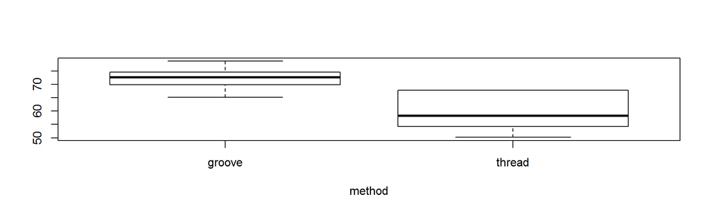

```r
boxplot(moment ~ method, data=subset(sample, type == "hexagon" & form == "corrugated"), xlab="method")
```

```r
aov_res34 <- aov(moment ~ method, data=subset(sample, type == "hexagon" & form == "corrugated"))
summary(aov_res34)
```

```
##             Df Sum Sq Mean Sq F value   Pr(>F)
## method       1  612.3   612.3   17.78 0.000863 ***
## Residuals   14  482.2    34.4
## ---
## Signif. codes:  0 '***' 0.001 '**' 0.01 '*' 0.05 '.' 0.1 ' ' 1
```

```r
EtaSq(aov_res34, type=1)
```

```
##           eta.sq eta.sq.part
## method 0.5594293   0.5594293
```

```r
TukeyHSD(aov_res34)
```

```
##   Tukey multiple comparisons of means
##     95% family-wise confidence level
##
## Fit: aov(formula = moment ~ method, data = subset(sample, type == "hexagon" & form == "corrugated"))
##
## $method
##                   diff      lwr       upr     p adj
## thread-groove -12.3725 -18.6663 -6.078703 0.0008628
```

Выводы следующие:

1. Шестиугольный тип + пазовый метод —> плоская форма лучше на 166, интервал [156, 175], p-value = 0.
2. Шестиугольный тип + резьбовой метод —> плоская форма лучше на 148, интервал [139, 157], p-value = 0.
3. Шестиугольный тип + плоская форма —> резьбовой метод хуже на 30, интервал [-41, -18], p-value = 6.45e-05.
4. Шестиугольный тип + гофрированная форма —> резьбовой метод хуже на 12, интервал [-18, -6], p-value = 0.0008628.

Проведём двухфакторный дисперсионный анализ для вентиляторов с пазовым методом соединения:

```r
aov_res4 <- aov(moment ~ type * form, data=subset(sample, method == "groove"))
summary(aov_res4)
```

```
##             Df Sum Sq Mean Sq F value   Pr(>F)
## type         1  19124   19124  303.33  < 2e-16 ***
## form         1 168174  168174 2667.43  < 2e-16 ***
## type:form    1   3505    3505   55.59 4.04e-08 ***
## Residuals   28   1765      63
## ---
## Signif. codes:  0 '***' 0.001 '**' 0.01 '*' 0.05 '.' 0.1 ' ' 1
```

```r
EtaSq(aov_res4, type=1)
```

```
##               eta.sq eta.sq.part
## type      0.09930942   0.9154911
## form      0.87332230   0.9896121
## type:form 0.01820104   0.6650413
```

Присутствует значимое межфакторное взаимодействие:

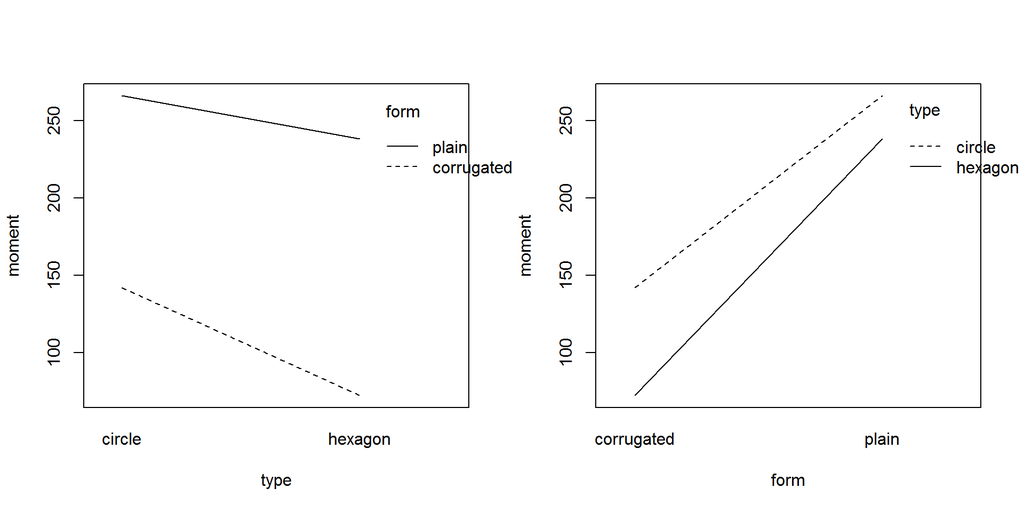

```r
par(mfrow=c(1,2))
with(sample[sample$method == "groove", ], interaction.plot(type, form, moment, xlab="type", ylab="moment"))
with(sample[sample$method == "groove", ], interaction.plot(form, type, moment, xlab="form", ylab="moment"))
```

Поэтому снова поделим выборку.

Однофакторный анализ для вентиляторов с пазовым соединением и плоской формой барабана:

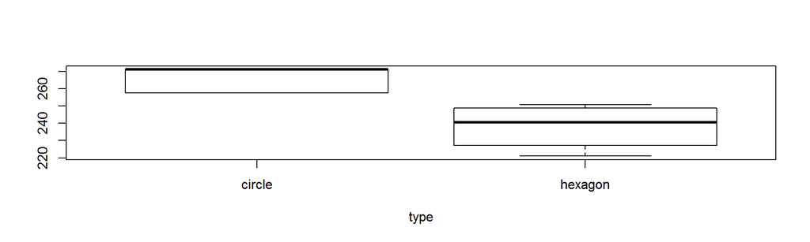

```r
boxplot(moment ~ type, data=subset(sample, form == "plain" & method == "groove"), xlab="type")
```

```r
aov_res41 <- aov(moment ~ type, data=subset(sample, form == "plain" & method == "groove"))
summary(aov_res41)
```

```
##             Df Sum Sq Mean Sq F value   Pr(>F)
## type         1   3127  3127.3   32.75 5.27e-05 ***
## Residuals   14   1337    95.5
## ---
## Signif. codes:  0 '***' 0.001 '**' 0.01 '*' 0.05 '.' 0.1 ' ' 1
```

```r
EtaSq(aov_res41, type=1)
```

```
##         eta.sq eta.sq.part
## type 0.7005399   0.7005399
```

```r
TukeyHSD(aov_res41)
```

```
##   Tukey multiple comparisons of means
##     95% family-wise confidence level
##
## Fit: aov(formula = moment ~ type, data = subset(sample, form == "plain" & method == "groove"))
##
## $type
##                     diff       lwr       upr    p adj
## hexagon-circle -27.96125 -38.44049 -17.48201 5.27e-05
```

Однофакторный анализ для вентиляторов с пазовым соединением и гофрированной формой барабана:

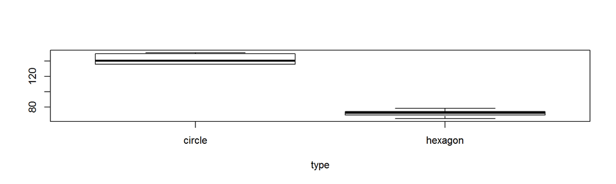

```r
boxplot(moment ~ type, data=subset(sample, form == "corrugated" & method == "groove"), xlab="type")
```

```r
aov_res42 <- aov(moment ~ type, data=subset(sample, form == "corrugated" & method == "groove"))
summary(aov_res42)
```

```
##             Df Sum Sq Mean Sq F value   Pr(>F)
## type         1  19501   19501   637.2 4.49e-13 ***
## Residuals   14    428      31
## ---
## Signif. codes:  0 '***' 0.001 '**' 0.01 '*' 0.05 '.' 0.1 ' ' 1
```

```r
EtaSq(aov_res42, type=1)
```

```
##         eta.sq eta.sq.part
## type 0.9785007   0.9785007
```

```r
TukeyHSD(aov_res42)
```

```
##   Tukey multiple comparisons of means
##     95% family-wise confidence level
##
## Fit: aov(formula = moment ~ type, data = subset(sample, form == "corrugated" & method == "groove"))
##
## $type
##                     diff       lwr       upr p adj
## hexagon-circle -69.82375 -75.75648 -63.89102     0
```

Однофакторный анализ для вентиляторов с пазовым соединением и круглым отверстием:

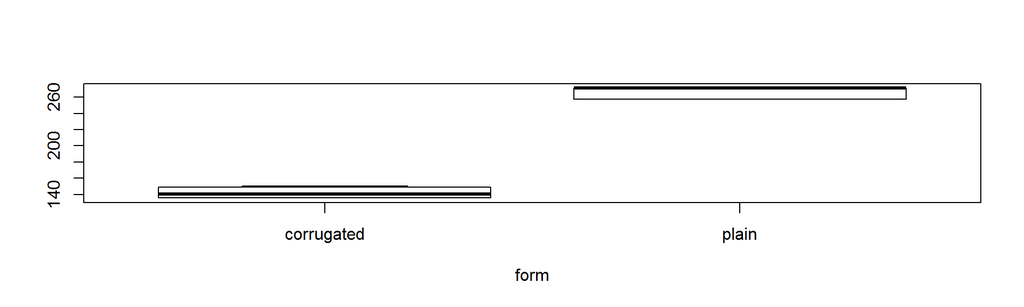

```r
boxplot(moment ~ form, data=subset(sample, type == "circle" & method == "groove"), xlab="form")
```

```r
aov_res43 <- aov(moment ~ form, data=subset(sample, type == "circle" & method == "groove"))
summary(aov_res43)
```

```
##             Df Sum Sq Mean Sq F value   Pr(>F)
## form         1  61561   61561    1314 3.05e-15 ***
## Residuals   14    656      47
## ---
## Signif. codes:  0 '***' 0.001 '**' 0.01 '*' 0.05 '.' 0.1 ' ' 1
```

```r
EtaSq(aov_res43, type=1)
```

```
##         eta.sq eta.sq.part
## form 0.9894562   0.9894562
```

```r
TukeyHSD(aov_res43)
```

```
##   Tukey multiple comparisons of means
##     95% family-wise confidence level
##
## Fit: aov(formula = moment ~ form, data = subset(sample, type == "circle" & method == "groove"))
##
## $form
##                      diff      lwr      upr p adj
## plain-corrugated 124.0575 116.7167 131.3983     0
```

Однофакторный анализ для вентиляторов с пазовым соединением и шестиугльным отверстием:

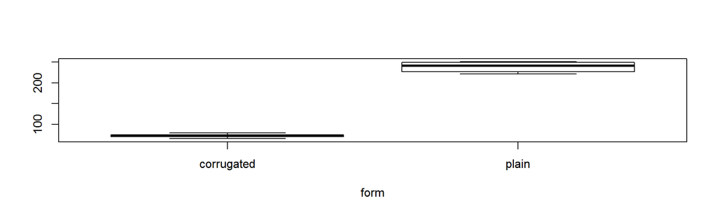

```r
boxplot(moment ~ form, data=subset(sample, type == "hexagon" & method == "groove"), xlab="form")
```

```r
aov_res44 <- aov(moment ~ form, data=subset(sample, type == "hexagon" & method == "groove"))
summary(aov_res44)
```

```
##             Df Sum Sq Mean Sq F value   Pr(>F)
## form         1 110118  110118    1390 2.07e-15 ***
## Residuals   14   1109      79
## ---
## Signif. codes:  0 '***' 0.001 '**' 0.01 '*' 0.05 '.' 0.1 ' ' 1
```

```r
EtaSq(aov_res44, type=1)
```

```
##         eta.sq eta.sq.part
## form 0.9900266   0.9900266
```

```r
TukeyHSD(aov_res44)
```

```
##   Tukey multiple comparisons of means
##     95% family-wise confidence level
##
## Fit: aov(formula = moment ~ form, data = subset(sample, type == "hexagon" & method == "groove"))
##
## $form
##                    diff      lwr      upr p adj
## plain-corrugated 165.92 156.3741 175.4659     0
```

Проведём двухфакторный дисперсионный анализ для вентиляторов с резьбовым методом соединения:

```r
aov_res5 <- aov(moment ~ type * form, data=subset(sample, method == "thread"))
summary(aov_res5)
```

```
##             Df Sum Sq Mean Sq  F value   Pr(>F)
## type         1   1293    1293   25.445 2.46e-05 ***
## form         1 186951  186951 3680.196  < 2e-16 ***
## type:form    1    155     155    3.058   0.0913 .
## Residuals   28   1422      51
## ---
## Signif. codes:  0 '***' 0.001 '**' 0.01 '*' 0.05 '.' 0.1 ' ' 1
```

```r
EtaSq(aov_res5, type=1)
```

```
##                 eta.sq eta.sq.part
## type      0.0068096051  0.47610126
## form      0.9848789041  0.99244916
## type:form 0.0008182456  0.09844751
```

Значимое межфакторное взаимодействие отсутствует:

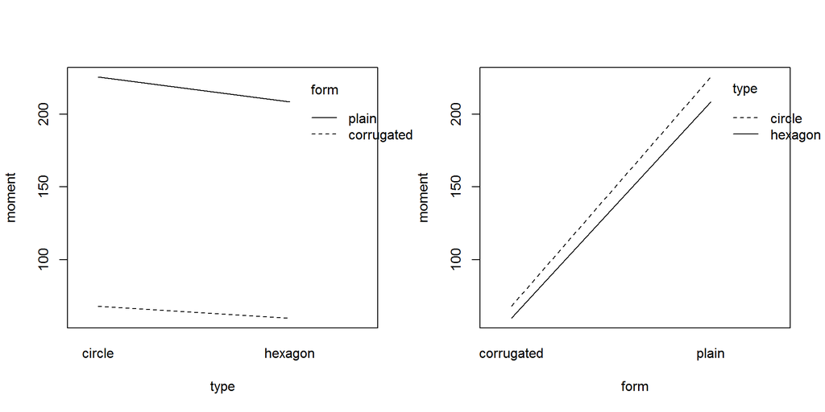

```r
par(mfrow=c(1,2))
with(sample[sample$method == "thread", ], interaction.plot(type, form, moment, xlab="type", ylab="moment"))
with(sample[sample$method == "thread", ], interaction.plot(form, type, moment, xlab="form", ylab="moment"))
```

```r
TukeyHSD(aov_res5, which="type")
```

```
##   Tukey multiple comparisons of means
##     95% family-wise confidence level
##
## Fit: aov(formula = moment ~ type * form, data = subset(sample, method == "thread"))
##
## $type
##                     diff       lwr       upr    p adj
## hexagon-circle -12.71125 -17.87303 -7.549469 2.46e-05
```

```r
TukeyHSD(aov_res5, which="form")
```

```
##   Tukey multiple comparisons of means
##     95% family-wise confidence level
##
## Fit: aov(formula = moment ~ type * form, data = subset(sample, method == "thread"))
##
## $form
##                      diff     lwr      upr p adj
## plain-corrugated 152.8687 147.707 158.0305     0
```

Проведём двухфакторный дисперсионный анализ для вентиляторов с гладким барабаном:

```r
aov_res6 <- aov(moment ~ type * method, data=subset(sample, form == "plain"))
summary(aov_res6)
```

```
##             Df Sum Sq Mean Sq F value   Pr(>F)
## type         1   4064    4064  50.056 1.07e-07 ***
## method       1   9942    9942 122.444 9.84e-12 ***
## type:method  1    235     235   2.896   0.0999 .
## Residuals   28   2273      81
## ---
## Signif. codes:  0 '***' 0.001 '**' 0.01 '*' 0.05 '.' 0.1 ' ' 1
```

```r
EtaSq(aov_res6, type=1)
```

```
##                 eta.sq eta.sq.part
## type        0.24610095  0.64128395
## method      0.60199654  0.81388451
## type:method 0.01424061  0.09374835
```

Значимое межфакторное взаимодействие отсутствует:

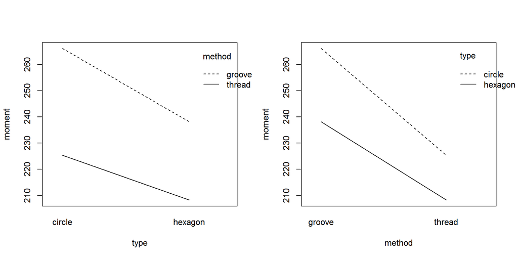

```r
par(mfrow=c(1,2))
with(sample[sample$form == "plain", ], interaction.plot(type, method, moment, xlab="type", ylab="moment"))
with(sample[sample$form == "plain", ], interaction.plot(method, type, moment, xlab="method", ylab="moment"))
```

```r
TukeyHSD(aov_res6, which="type")
```

```
##   Tukey multiple comparisons of means
##     95% family-wise confidence level
##
## Fit: aov(formula = moment ~ type * method, data = subset(sample, form == "plain"))
##
## $type
##                     diff       lwr       upr p adj
## hexagon-circle -22.53938 -29.06511 -16.01364 1e-07
```

```r
TukeyHSD(aov_res6, which="method")
```

```
##   Tukey multiple comparisons of means
##     95% family-wise confidence level
##
## Fit: aov(formula = moment ~ type * method, data = subset(sample, form == "plain"))
##
## $method
##                    diff       lwr       upr p adj
## thread-groove -35.25187 -41.77761 -28.72614     0
```

Выводы следующие:

1. Плоская форма —> шестиугольный тип хуже на 22, интервал [-29, -16], p-value = 1e-07.
2. Плоская форма —> резьбовой тип хуже на 35, интервал [-41, -28], p-value = 0.

Проведём двухфакторный дисперсионный анализ для вентиляторов с гофрированным барабаном:

```r
aov_res7 <- aov(moment ~ type * method, data=subset(sample, form == "corrugated"))
summary(aov_res7)
```

```
##             Df Sum Sq Mean Sq F value  Pr(>F)
## type         1  12208   12208   373.9 < 2e-16 ***
## method       1  14883   14883   455.8 < 2e-16 ***
## type:method  1   7569    7569   231.8 4.5e-15 ***
## Residuals   28    914      33
## ---
## Signif. codes:  0 '***' 0.001 '**' 0.01 '*' 0.05 '.' 0.1 ' ' 1
```

```r
EtaSq(aov_res7, type=1)
```

```
##                eta.sq eta.sq.part
## type        0.3431730   0.9303256
## method      0.4183579   0.9421224
## type:method 0.2127680   0.8922247
```

Присутствует значимое межфакторное взаимодействие:

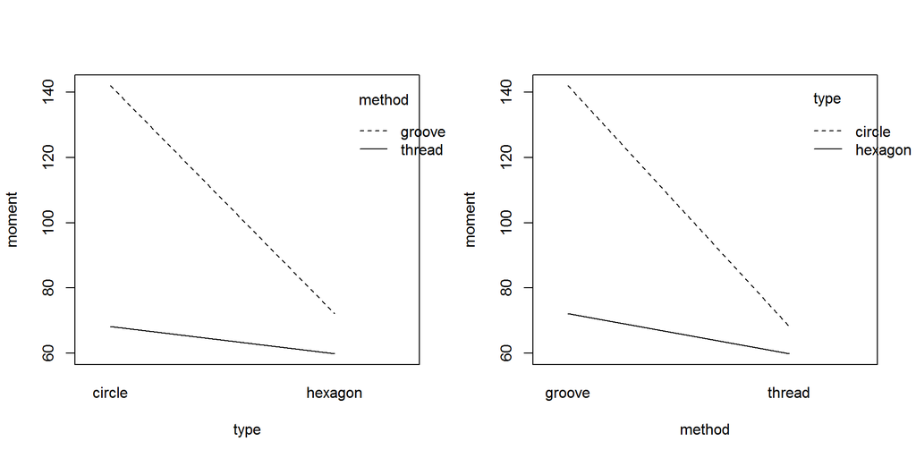

```r
par(mfrow=c(1,2))
with(sample[sample$form == "corrugated", ], interaction.plot(type, method, moment, xlab="type", ylab="moment"))
with(sample[sample$form == "corrugated", ], interaction.plot(method, type, moment, xlab="method", ylab="moment"))
```

Поэтому снова поделим выборку.

Однофакторный анализ для вентиляторов с гофрированным барабаном и круглым отверстием:

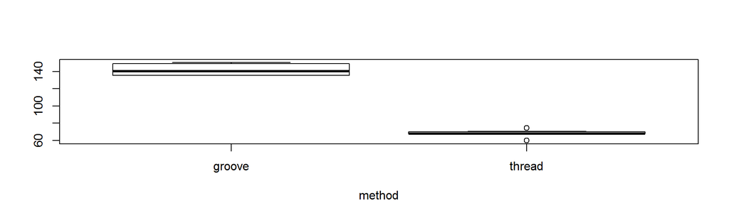

```r
boxplot(moment ~ method, data=subset(sample, type == "circle" & form == "corrugated"), xlab="method")
```

```r
aov_res71 <- aov(moment ~ method, data=subset(sample, type == "circle" & form == "corrugated"))
summary(aov_res71)
```

```
##             Df Sum Sq Mean Sq F value   Pr(>F)
## method       1  21840   21840   707.6 2.19e-13 ***
## Residuals   14    432      31
## ---
## Signif. codes:  0 '***' 0.001 '**' 0.01 '*' 0.05 '.' 0.1 ' ' 1
```

```r
EtaSq(aov_res71, type=1)
```

```
##           eta.sq eta.sq.part
## method 0.9805995   0.9805995
```

```r
TukeyHSD(aov_res71)
```

```
##   Tukey multiple comparisons of means
##     95% family-wise confidence level
##
## Fit: aov(formula = moment ~ method, data = subset(sample, type == "circle" & form == "corrugated"))
##
## $method
##                    diff       lwr       upr p adj
## thread-groove -73.89125 -79.84888 -67.93362     0
```

Однофакторный анализ для вентиляторов с гофрированным барабаном и шестиугольным отверстием:

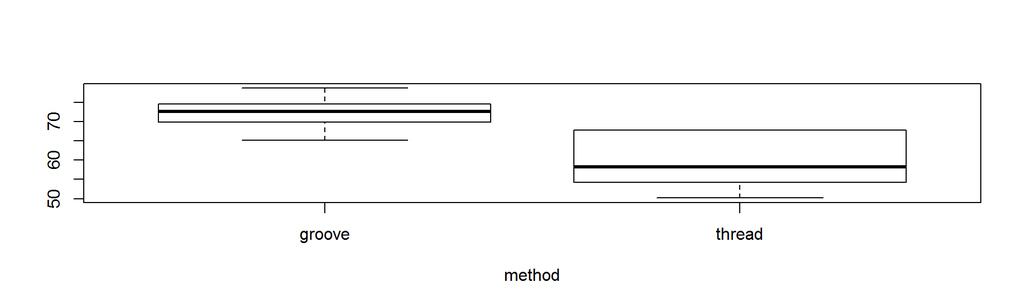

```r
boxplot(moment ~ method, data=subset(sample, type == "hexagon" & form == "corrugated"), xlab="method")
```

```r
aov_res72 <- aov(moment ~ method, data=subset(sample, type == "hexagon" & form == "corrugated"))
summary(aov_res72)
```

```
##             Df Sum Sq Mean Sq F value   Pr(>F)
## method       1  612.3   612.3   17.78 0.000863 ***
## Residuals   14  482.2    34.4
## ---
## Signif. codes:  0 '***' 0.001 '**' 0.01 '*' 0.05 '.' 0.1 ' ' 1
```

```r
EtaSq(aov_res72, type=1)
```

```
##           eta.sq eta.sq.part
## method 0.5594293   0.5594293
```

```r
TukeyHSD(aov_res72)
```

```
##   Tukey multiple comparisons of means
##     95% family-wise confidence level
##
## Fit: aov(formula = moment ~ method, data = subset(sample, type == "hexagon" & form == "corrugated"))
##
## $method
##                   diff      lwr       upr     p adj
## thread-groove -12.3725 -18.6663 -6.078703 0.0008628
```

Однофакторный анализ для вентиляторов с гофрированным барабаном и пазовым соединением:

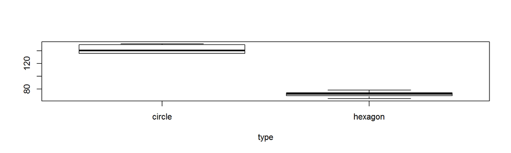

```r
boxplot(moment ~ type, data=subset(sample, method == "groove" & form == "corrugated"), xlab="type")
```

```r
aov_res73 <- aov(moment ~ type, data=subset(sample, method == "groove" & form == "corrugated"))
summary(aov_res73)
```

```
##             Df Sum Sq Mean Sq F value   Pr(>F)
## type         1  19501   19501   637.2 4.49e-13 ***
## Residuals   14    428      31
## ---
## Signif. codes:  0 '***' 0.001 '**' 0.01 '*' 0.05 '.' 0.1 ' ' 1
```

```r
EtaSq(aov_res73, type=1)
```

```
##         eta.sq eta.sq.part
## type 0.9785007   0.9785007
```

```r
TukeyHSD(aov_res73)
```

```
##   Tukey multiple comparisons of means
##     95% family-wise confidence level
##
## Fit: aov(formula = moment ~ type, data = subset(sample, method == "groove" & form == "corrugated"))
##
## $type
##                     diff       lwr       upr p adj
## hexagon-circle -69.82375 -75.75648 -63.89102     0
```

Однофакторный анализ для вентиляторов с гофрированным барабаном и резьбовым соединением:

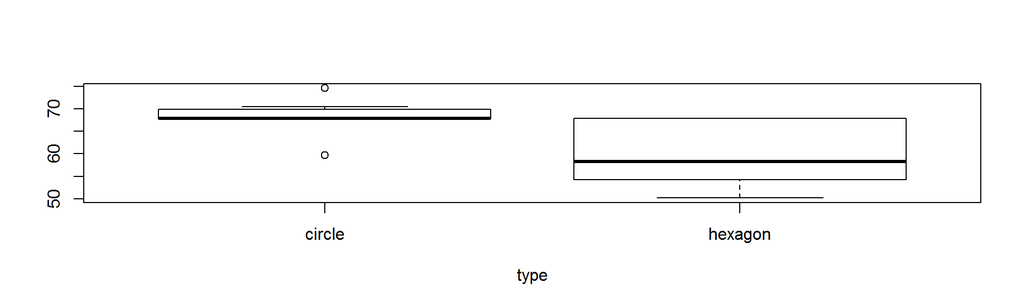

```r
boxplot(moment ~ type, data=subset(sample, method == "thread" & form == "corrugated"), xlab="type")
```

```r
aov_res74 <- aov(moment ~ type, data=subset(sample, method == "thread" & form == "corrugated"))
summary(aov_res74)
```

```
##             Df Sum Sq Mean Sq F value Pr(>F)
## type         1  275.9   275.9    7.95 0.0136 *
## Residuals   14  485.8    34.7
## ---
## Signif. codes:  0 '***' 0.001 '**' 0.01 '*' 0.05 '.' 0.1 ' ' 1
```

```r
EtaSq(aov_res74, type=1)
```

```
##         eta.sq eta.sq.part
## type 0.3621979   0.3621979
```

```r
TukeyHSD(aov_res74)
```

```
##   Tukey multiple comparisons of means
##     95% family-wise confidence level
##
## Fit: aov(formula = moment ~ type, data = subset(sample, method == "thread" & form == "corrugated"))
##
## $type
##                  diff       lwr       upr     p adj
## hexagon-circle -8.305 -14.62227 -1.987726 0.0136423
```

Выводы следующие:

1. Гофрированная форма + круглый тип —> резьбовой метод хуже на 74, интервал [-80, -68], p-value = 0.
2. Гофрированная форма + шестиугольный тип —> резьбовой метод хуже на 12, интервал [-18, -6], p-value = 0.0008628.
3. Гофрированная форма + пазовый метод —> шестиугольный тип хуже на 70, интервал [-75, -64], p-value = 0.
4. Гофрированная форма + резьбовой метод —> шестиугольный тип хуже на 8, интервал [-14, -2], p-value = 0.0136423.

- круглый тип отверстия даёт устойчивость выше, чем шестиугольный;
- пазовый метод соединения даёт устойчивость выше, чем резьбовой;
- гладкая форма барабана даёт устойчивость выше, чем гофрированная.